# presentation

## Definition and milestones

- **Business model**: A business model describes the rationale of how an organization creates, delivers, and captures value.
- Milestones in this century:
  - **2004**: Alexander Osterwalder introduces the Business Model Canvas.
  - **2010**: Business Model Generation book is published.
  - **2015**: Business Model Navigator book is published.
- Software
  - [Business model navigator](https://businessmodelnavigator.com/)
  - [Strategyzer’s Business Model Canvas](https://www.strategyzer.com/library/the-business-model-canvas)

## Business model canvas

[figure not shown]

## Business models extensions

## Tripple layer business model (Joyce and Paquin, 2016)

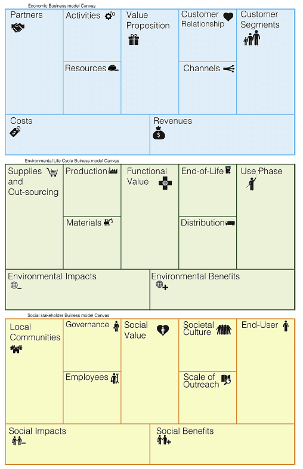

## Threebility (Gerlach, 2015)

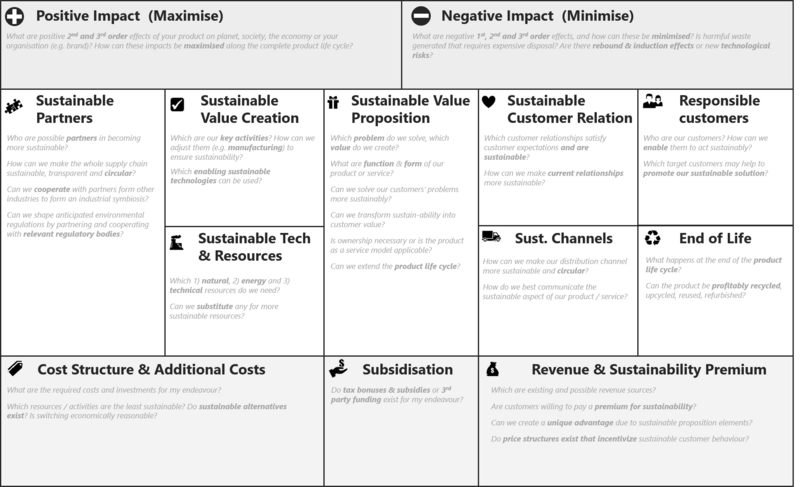

## ProGlreg business model (2023)

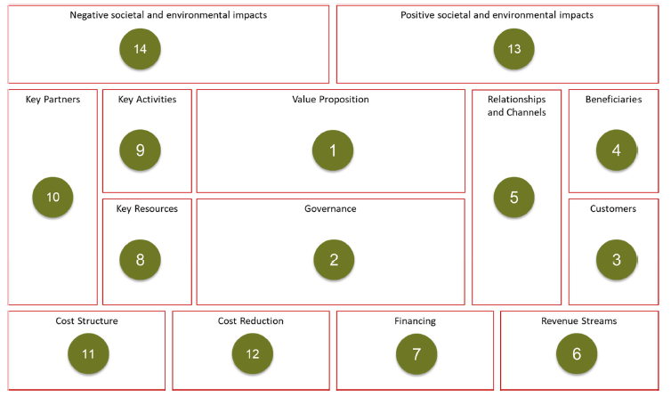

## ISO 59010 circular economy (2024)

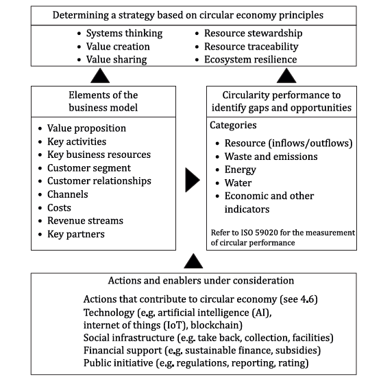

## Interviews and surveys following BS

[See here](https://mislav.quarto.pub/dawetrest-business-model-questionnaire/)

## MD demo example

## Value Proposition

- **Increasing biodiversity**: Bringing back native species and improving wetlands through water management and the green hatchery.
- **Climate Resilience**: Carbon sequestration and improving water quality.
- **Sustainable Development in NBS**: Promoting regenerative tourism, sports fisheries, and community involvement in restoration efforts.

## Key Partners

- **Croatian Waters (HRVODE)**: Hydrological works and floodplain restoration.
- **University of Zagreb (UZ-FSB)**: Technology development and digital platform management.
- **CEKOM**: Data collection and strategy development.
- **Local and Regional Authorities**: Coordination of on-ground activities.
- **NGOs and SMEs**: Supporting community engagement and eco-tourism.

## Key Resources

- **Natural Resources**: Wetlands and native fish species.
- **Human Resources**: Biodiversity experts, local labor, and scientific researchers.
- **Technological Resources**: Centralized data repository and monitoring tools.
- **Financial Resources**: EU Horizon Europe funding.
- **Green Hatchery Infrastructure**: Aquaculture systems with renewable energy sources.

## Key Activities

- **Hydrological Restoration**: Removing barriers and improving water flows.
- **Green Hatchery Operations**: Cultivating native fish species.
- **Biodiversity Monitoring**: Digital tools for tracking ecological health.
- **Community Engagement**: Workshops, citizen science, and local job creation.
- **Sustainable Aquaculture**: Long-term fishery management and economic development.

## Customer Segments

- **Local Communities**: Benefiting from restored ecosystems and new economic opportunities.
- **Regional and National Authorities**: Supporting environmental and flood management policies?
- **Environmental Agencies**: Using the DEMO as a model for wetland restoration.
- **Regenerative tourism community**: Leveraging the restored ecosystems for sustainable tourism.

## Channels

- **Digital Platforms**: Website, social media (Facebook, YouTube), and newsletters.
- **Community Events**: Workshops, and participatory monitoring.
- **Printed Materials**: Flyers, posters, and press releases.
- **International Conferences**: Sharing knowledge with the broader scientific and policy communities.
- **Portal** - Centralized data repository and monitoring tools.

## Revenue Streams

- **Regenerative Tourism and Sports Fisheries**: Income from guided tours, fishing permits, and eco-lodging.
- **Sustainable Aquaculture**: Sale of native fish species to local markets.
- **Reed and Plant Harvesting**: Sustainable use of wetland plants for bio-based materials.
- **Environmental Consulting**: Offering expertise in wetland restoration to other regions.
- **Data API** - subscriptoin on the portal?

## Cost Structure

- **Restoration Costs**: Hydrological engineering, hatchery operations, and maintenance.
- **Technology and Monitoring**: Sensors, drones, and data management systems.
- **Community Engagement**: Workshops, educational programs, and local involvement.
- **Project Management**: Administrative costs, legal compliance, and project coordination.

## Data and tools for dynamic reporting and interactivity

## Data Used in Business Model Preparation

- **Environmental Data** - water quality, biodiversity indicators, carbon sequestration data.
- **Socio-economic Data** - macro data, local employment, business subject dynamics.
- **Community and Stakeholder Feedback** - community surveys, interviews.

## Data Science principles

- **Dynamic** - automatic updates when new data is ingested or parameters are changed.
- **Interactive** - allow users to explore data and insights.
- **Reproducible** - analyses should be reproducible by other teams using the same datasets and methods.
- **Automated Data Pipelines** - automate data collection, cleaning, and reporting to ensure consistent updates.
- **Versioning and Traceability** - track all changes to data, code, and reports to ensure they can be replicated or rolled back.
- **Open source** - use open-source tools and libraries to ensure transparency and collaboration.
- **Example** - [MD Demo business model](https://forensis.shinyapps.io/dawetrest/)